# Q2 Term Paper

Ding Yang Wang

2022-06-03

# Data Preperation

```r
Germany_health <- read.csv("/Users/deweywang/Desktop/LMU/2\ -\ semester/Pretty\ Plots\ -\ Visualizing\ Statistical\ Data/final\ assignment/Data\ for\ termpaper-20220528/Germany_overall_health.csv")

colnames(Germany_health)[1:2] <- c("state", "state id")
```

## Q2: (a) Visualize the data in a way that allows the viewer to assess the impact of education level and gender. Describe in your own words what has the bigger impact on the perceived health: Gender or education level.

Data preparation:

```r
edu_gender <- Germany_health %>%
  filter(state == "Deutschland" & Standard == 1 & age_group == "Gesamt" & education != "all" & gender != "both")
```

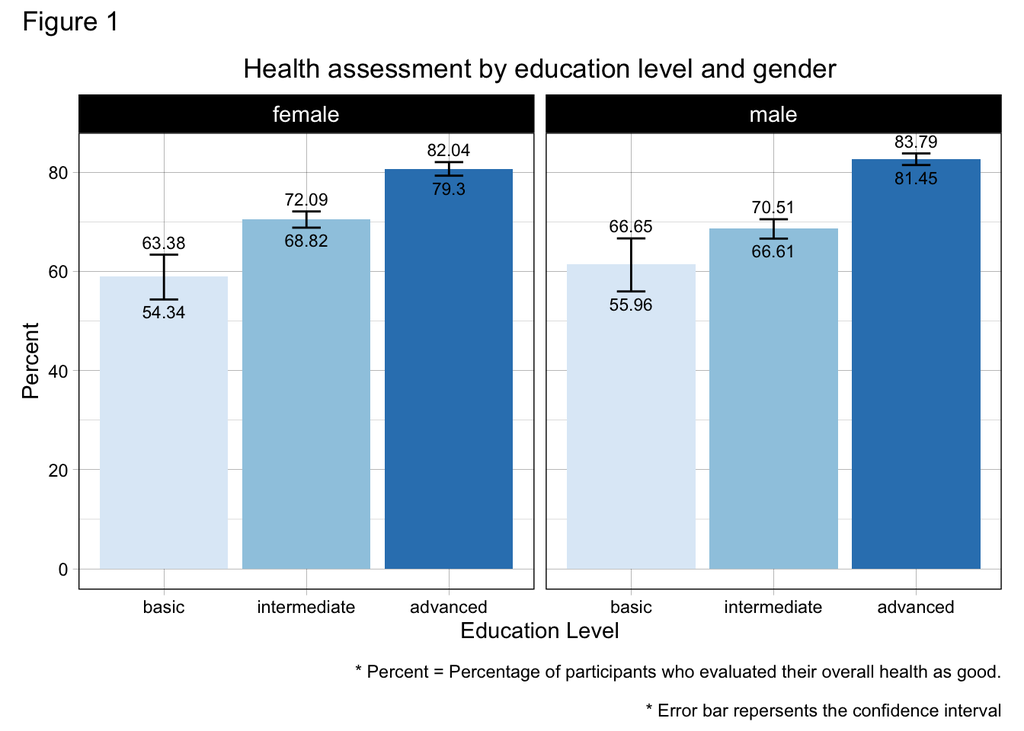

```r
edu_gender$education <- factor(edu_gender$education,
                              levels = c("basic", "intermediate", "advanced"))


edu_gender_Fig <- edu_gender %>% ggplot(aes(x = education, y = Percent,fill = education))+
  geom_col() +
  facet_grid(~gender)+
  geom_errorbar(aes(ymin=LowerCL, ymax=UpperCL),
                width=.2,                    # Width of the error bars
                position=position_dodge(.9))  +
  geom_text(aes(label = round(UpperCL, digits = 2), y = UpperCL), vjust = -.5, size = 3) +
  geom_text(aes(label = round(LowerCL, digits = 2), y = LowerCL), vjust = 1.5, size = 3) +
  theme(legend.position = "none",
        plot.title=element_text(hjust = 0.5, size = rel(1.2)),
        axis.text        = element_text(colour = "black", size = rel(0.8)),
        axis.ticks       = element_line(colour = "black", size = rel(0.1)),
        # NB: match the *visual* thickness of axis ticks to the panel border
        #     0.5 clipped looks like 0.25

        # pure black panel border and grid lines, but thinner
        panel.background = element_blank(),
        panel.border     = element_rect(fill = NA, colour = "black", size = rel(1)),
        panel.grid       = element_line(colour = "black"),
        panel.grid.major = element_line(size = rel(0.1)),
        panel.grid.minor = element_line(size = rel(0.05)),

        # strips with black background and white text
        strip.background = element_rect(fill = "black"),
        strip.text       = element_text(
          colour = "white",
          size = rel(1),
          margin = margin(0.8 * 5.5, 0.8 * 5.5, 0.8 * 5.5, 0.8 * 5.5)
        )
        )+
  scale_fill_brewer("Dark2") +
  labs(y = "Percent",
       x = "Education Level",
       title = "Health assessment by education level and gender")

edu_gender_Fig +
  plot_annotation(
    title = 'Figure 1',
    caption = "* Percent = Percentage of participants who evaluated their overall health as good.\n
                  * Error bar repersents the confidence interval")
```

**Answer:** From Fig.1, we can easily observe that there is more significant difference between the education level. Hence, I think the education level has a bigger impact on perceived health than gender.

## Q2: (b) Make another plot that assess differences between age groups and genders.

Data preparation: Here, I didn’t use Standard == 1 is because we can only find Standard == 0 in the raw data.

```r
age_gender <- Germany_health %>% filter(state == "Deutschland" & Standard == 0 & age_group != "Gesamt" & education == "all" & gender != "both")
```

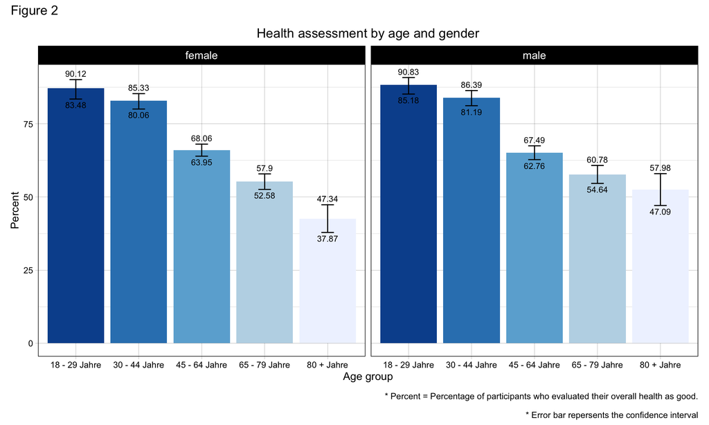

```r
age_gender_Fig <- age_gender %>% ggplot(aes(x = age_group, y = Percent,fill = age_group))+
  geom_col() +
  facet_grid(~gender)+
  geom_errorbar(aes(ymin=LowerCL, ymax=UpperCL),
                width=.2,                    # Width of the error bars
                position=position_dodge(.9))  +
  geom_text(aes(label = round(UpperCL, digits = 2), y = UpperCL), vjust = -.5, size = 3) +
  geom_text(aes(label = round(LowerCL, digits = 2), y = LowerCL), vjust = 1.5, size = 3) +
  theme(legend.position = "none",
        plot.title=element_text(hjust = 0.5, size = rel(1.2)),
        axis.text        = element_text(colour = "black", size = rel(0.8)),
        axis.ticks       = element_line(colour = "black", size = rel(0.1)),
        # NB: match the *visual* thickness of axis ticks to the panel border
        #     0.5 clipped looks like 0.25

        # pure black panel border and grid lines, but thinner
        panel.background = element_blank(),
        panel.border     = element_rect(fill = NA, colour = "black", size = rel(1)),
        panel.grid       = element_line(colour = "black"),
        panel.grid.major = element_line(size = rel(0.1)),
        panel.grid.minor = element_line(size = rel(0.05)),

        # strips with black background and white text
        strip.background = element_rect(fill = "black"),
        strip.text       = element_text(
          colour = "white",
          size = rel(1),
          margin = margin(0.8 * 5.5, 0.8 * 5.5, 0.8 * 5.5, 0.8 * 5.5)
        )
  )+
  scale_fill_brewer("Dark2",   direction = -1) +
  labs(y = "Percent",
       x = "Age group",
       title = "Health assessment by age and gender")

age_gender_Fig+
  plot_annotation(
    title = 'Figure 2',
    caption = "* Percent = Percentage of participants who evaluated their overall health as good.\n
                  * Error bar repersents the confidence interval")
```

**Answer:** From Fig.2, it shows that there is more significant difference between different age group. Thus, I think the age has a bigger impact on perceived health than gender.

## Q2: (c) Are there still differences between the ’old’ and the ’new’ Bundesländer (former Eastern Germany: Mecklenburg- Vorpommern, Thüringen, Sachsen-Anhalt, Brandenburg, Sachsen). Depict the percentage of people who assess their health as good in the context of a map of Germany.

Here, I filter out the data that has been standardized as the data to visualize in map plot because I use both gender with all age group.

```r
germany_all <- Germany_health %>% filter(state != "Deutschland" ,
                                         gender == "both",
                                         Standard == "1",
                                         age_group == "Gesamt")
```

Here, I splite the map data into old Bundesländer and the rest of them to help me to easy to reconginze from the map plot.

```r
shape <- read_sf(dsn = "Data for termpaper-20220528/DEU_adm/", layer = "DEU_adm1")

old <- shape %>% filter(NAME_1 == "Mecklenburg-Vorpommern" | NAME_1 == "Thüringen"|
                NAME_1 ==  "Sachsen-Anhalt" | NAME_1 ==  "Sachsen"|
                NAME_1 =="Brandenburg")

old_test <- old%>%
  inner_join(germany_all,  by = c("NAME_1" = "state"))

new <- shape %>% filter(NAME_1 != "Mecklenburg-Vorpommern" & NAME_1 != "Thüringen"&
                          NAME_1 !=  "Sachsen-Anhalt" & NAME_1 !=  "Sachsen"&
                          NAME_1 !="Brandenburg")
new_test <- new%>%
  inner_join(germany_all,  by = c("NAME_1" = "state"))
```

I also want to mark the name of the state on the map plot. Thus, I need the center of lat and long in the state to put their name on it.

```r
Germany_id <- read.csv("Data for termpaper-20220528/DEU_adm/DEU_adm1.csv")

shape_county_1 <- readShapeSpatial("Data for termpaper-20220528/DEU_adm/DEU_adm1.shp")

germany_map <- fortify(shape_county_1)

distcenters <- plyr::ddply(germany_map,"id", summarize, clat = mean(lat), clong = mean(long))

distcenters$id <- as.integer(distcenters$id)+1

distcenters <- distcenters%>%
  inner_join(Germany_id, by = c("id" ="ID_1"))
```

After having the lat and long of the state center, I adjust some of them to aviod over plotting.

```r
##for Brandenburg
distcenters[10,2] <- 52.2

##for Mecklenburg-Vorpommern
distcenters[14,3] <- 12.5
distcenters[14,2] <- 53.8

##for Schleswig-Holstein
distcenters[7,3] <- 9.85
distcenters[7,2] <- 54

##for Niedersachsen
distcenters[15,3] <- 8.9
distcenters[15,2] <- 52.8
##for Baden-Württemberg
distcenters[1,3] <- 8.89
distcenters[1,2] <- 48.5
```

Eventually, I make a map plot that can easily recongize which states are old Bundesländer.

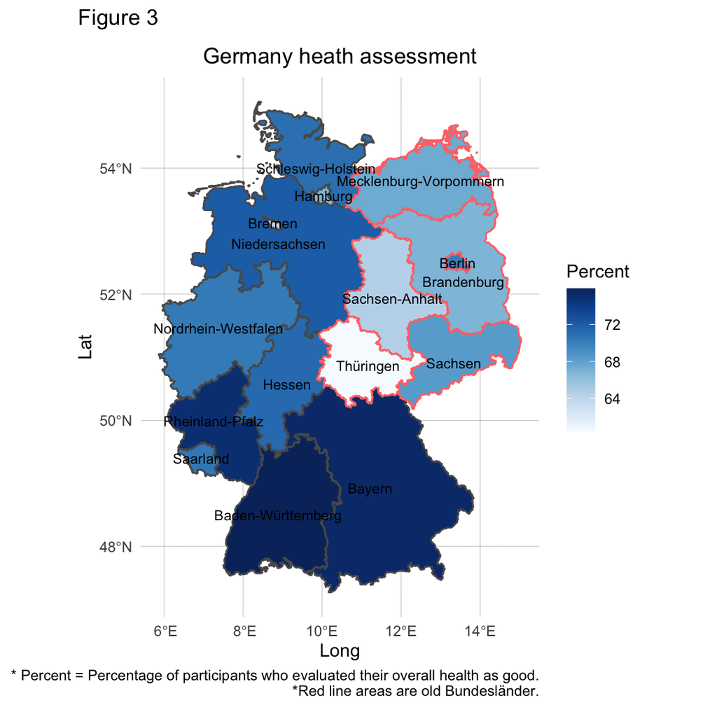

```r
map_Geramny_assessment<- ggplot() +
  geom_sf(data = new_test, aes(fill = Percent)) +
  geom_sf(data = old_test, aes(fill = Percent), color = "#FF7575") +
  scale_fill_gradientn(colours  = brewer.pal(9,"Blues"))+
  theme(
        plot.title=element_text(hjust = 0.5, size = rel(1.2)),
    axis.ticks      = element_blank(),
      legend.background = element_blank(),
      legend.key        = element_blank(),
      panel.background  = element_blank(),
      panel.border      = element_blank(),
      strip.background  = element_blank(),
      plot.background   = element_blank(),
      panel.grid       = element_line(colour = "black"),
        panel.grid.major = element_line(size = rel(0.1)),
        panel.grid.minor = element_line(size = rel(0.05)))+
  labs(x = "Long",
       y = "Lat",
       caption = "* Percent = Percentage of participants who evaluated their overall health as good.\n*Red line areas are old Bundesländer.",
       title = "Germany heath assessment")

map_Geramny_assessment +
  geom_text(data = distcenters, aes(x = clong, y = clat, label = NAME_1), size = 3)+
  plot_annotation(
    title = 'Figure 3')
```

## Q2: (d) Arrange all 3 plots in a panel. Don’t forget the figure legend with your interpretations.

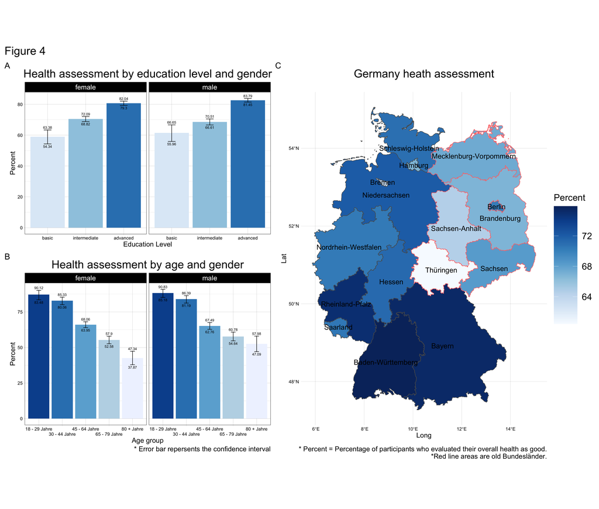

```r
edu_gender_Fig <- edu_gender_Fig+
  theme(legend.position = "none",
        plot.title=element_text(hjust = 0.5, size = rel(1.7)),
        axis.text        = element_text(colour = "black", size = rel(1)),
        axis.ticks       = element_line(colour = "black", size = rel(0.1)),
        axis.title = element_text(colour = "black", size = rel(1.5)),

        # NB: match the *visual* thickness of axis ticks to the panel border
        #     0.5 clipped looks like 0.25

        # pure black panel border and grid lines, but thinner
        panel.background = element_blank(),
        panel.border     = element_rect(fill = NA, colour = "black", size = rel(1)),
        panel.grid       = element_line(colour = "black"),
        panel.grid.major = element_line(size = rel(0.1)),
        panel.grid.minor = element_line(size = rel(0.05)),

        # strips with black background and white text
        strip.background = element_rect(fill = "black"),
        strip.text       = element_text(
          colour = "white",
          size = rel(1.5),
          margin = margin(0.8 * 5.5, 0.8 * 5.5, 0.8 * 5.5, 0.8 * 5.5)
        )
  )

age_gender_Fig <- age_gender_Fig + labs(caption = "* Error bar repersents the confidence interval")+
  guides( x= guide_axis(n.dodge = 2))+
  theme(legend.position = "none",
        plot.caption = element_text(size = rel(1.5)),
        plot.title=element_text(hjust = 0.5, size = rel(1.7)),
        axis.text        = element_text(colour = "black", size = rel(1)),
        axis.ticks       = element_line(colour = "black", size = rel(0.1)),
        axis.title = element_text(colour = "black", size = rel(1.5)),
        # NB: match the *visual* thickness of axis ticks to the panel border
        #     0.5 clipped looks like 0.25

        # pure black panel border and grid lines, but thinner
        panel.background = element_blank(),
        panel.border     = element_rect(fill = NA, colour = "black", size = rel(1)),
        panel.grid       = element_line(colour = "black"),
        panel.grid.major = element_line(size = rel(0.1)),
        panel.grid.minor = element_line(size = rel(0.05)),

        # strips with black background and white text
        strip.background = element_rect(fill = "black"),
        strip.text       = element_text(
          colour = "white",
          size = rel(1.5),
          margin = margin(0.8 * 5.5, 0.8 * 5.5, 0.8 * 5.5, 0.8 * 5.5)
        )
  )

map_Geramny_assessment <- map_Geramny_assessment+
  geom_text(data = distcenters, aes(x = clong, y = clat, label = NAME_1), size = 6)+
  theme(        plot.caption = element_text(size = rel(1.5)),
    axis.ticks      = element_blank(),
    axis.text        = element_text(colour = "black", size = rel(1)),
    legend.key.size = unit(2, 'cm'),
    legend.text = element_text(colour = "black", size = rel(2)),
    legend.title = element_text(colour = "black", size = rel(2)),
            axis.title = element_text(colour = "black", size = rel(1.5)),
            plot.title=element_text(hjust = 0.5, size = rel(1.7)),
      legend.background = element_blank(),
      legend.key        = element_blank(),
      panel.background  = element_blank(),
      panel.border      = element_blank(),
      strip.background  = element_blank(),
      plot.background   = element_blank(),
      panel.grid       = element_line(colour = "black"),
        panel.grid.major = element_line(size = rel(0.1)),
        panel.grid.minor = element_line(size = rel(0.05)))+
  labs(title = "Germany heath assessment")

((edu_gender_Fig/age_gender_Fig)| map_Geramny_assessment)+
  plot_annotation(
    title = 'Figure 4',
    tag_levels = 'A') &
  theme(plot.title = element_text(size = 27),
                plot.tag = element_text(size = 20))
```

Fig. 4: Plot A and Plot B show the percent difference under different factors. Plot C shows the percentage in different states in Germany.

# Packages & R verion